# Clusterized Hong Kong Daily Passenger Flows Report via MSTL & SARIMAX methods

Cheung Cheuk Hin Alvin @alvin_ccha

2026-05-30

## Abstract

This report presents a statistical framework for analyzing and forecasting Hong Kong’s daily border passenger immigration and emigration throughput. Starting with the clustering of 17 control points into 4 classes using a distance method over time on 3 types of visitors, it utilizes a nested dual-layer Seasonal-Trend Decomposition using Loess (MSTL) architecture; the daily time series is separated into macroscopic annual trajectories ($T_1=365$) and microscopic intra-week rhythms ($T_2=7$), then aims to briefly infer the trend and seasonal effect. The secondary residual stream is modeled via competing Linear Regression (MSTLLR) and Autoregressive Integrated Moving Average with Exogenous Regressors (MSTLSARIMAX) architectures to quantify policy-induced shocks. Model execution across passenger sub-types evaluates performance using Root Mean Squared Error (RMSE), $R^2$, and Kullback-Leibler (KL) divergence. Diagnostics reveal that while MSTLLR leaves significant residual serial correlation, MSTLSARIMAX flattens this drawback as shown by the Autocorrelation Function (ACF) profile, driving the KL divergence downwards and achieving superior structural feature extraction. However, MSTLSARIMAX lengthens modal fitting time and increases the model complexity, and is thus lower in efficiency than MSTLLR. This framework will also provide robust predictive realizations for operational optimization and border infrastructure management.

## Introduction

The cross-border movement of passengers in Hong Kong is an essential indicator of economic vitality, regional integration, and structural response to regulatory interventions. However, modeling daily entry and exit passenger streams presents significant statistical challenges due to the simultaneous superposition of multi-frequency periodicities, secular trends, and high-magnitude stochastic volatility induced by sudden regulatory shifts or economic policy changes.

Traditional time series methodologies often struggle to isolate long-term seasonal movements (such as annual holidays) from short-term rhythms (such as weekend commuting patterns), while simultaneously isolating the exact mathematical impact of policy shifts. This study addresses these issues by implementing a multi-layer hybrid time series infrastructure. By cascading non-parametric smoothing techniques (MSTL) with explicit parametric tracking of innovations(LR & SARIMAX) following, we capture the latent properties governing passenger flow dynamics across various transport modalities and demographic groups.

## Part 1: Clustering of Control Points

To establish a logical operational hierarchy across Hong Kong’s control points, an unsupervised learning technique, clustering with Ward’s method, is developed. The core objective is to group the control points based on the merged distance among time and passenger types for Arrival and Departure data, respectively. Thus, this method enables the systematic exclusion of non-operational and highly sparse nodes prior to conducting time series decomposition and forecasting.

### Mathematical Formulation of Multi-Cohort Distance

Let $i$ and $j$ represent individual boundary control points within the network of $N = 17$ nodes. Let $t \in \{1, 2, \dots, T\}$ denote the daily time steps over the observation period. The passenger flows are divided into three demographic cohorts: $v=1$ for Hong Kong Residents, $v=2$ for Mainland Visitors, and $v=3$ for Other International Visitors.

$\Delta_{A,v}(i,j) = \frac{1}{T} \sum_{t=1}^T |A_{i,v}(t) - A_{j,v}(t)|^2$

$\Delta_{D,v}(i,j) = \frac{1}{T} \sum_{t=1}^T |D_{i,v}(t) - D_{j,v}(t)|^2$

The resulting symmetric distance matrix $\mathbf{D} \in \mathbb{R}^{N \times N}$, where $D_{i,j} = d(i, j)$, separating Arrival and Departure initially, provides the quantitative basis for mapping the structural proximity of the control points based purely on their dynamic demographic draw.

### Hierarchical Clustering and Taxonomy Dendrogram

Using the derived distance matrix $\mathbf{D}$, an agglomerative hierarchical cluster analysis is executed using Ward’s minimum variance method. Ward’s method optimizes a global objective by choosing to merge clusters that minimize the total within-cluster variance. Specifically, the linkage distance between two disjoint clusters $C_A$ and $C_B$ is quantified as the incremental increase in the total error sum of squares ($ESS$) resulting from their amalgamation:

$D_{\text{Ward}}(C_A, C_B) = ESS(C_A \cup C_B) - \bigl[ ESS(C_A) + ESS(C_B) \bigr] = \frac{|C_A||C_B|}{|C_A| + |C_B|} \|\mathbf{m}_A - \mathbf{m}_B\|_2^2$

```r
library(readr)
library(dplyr)
```

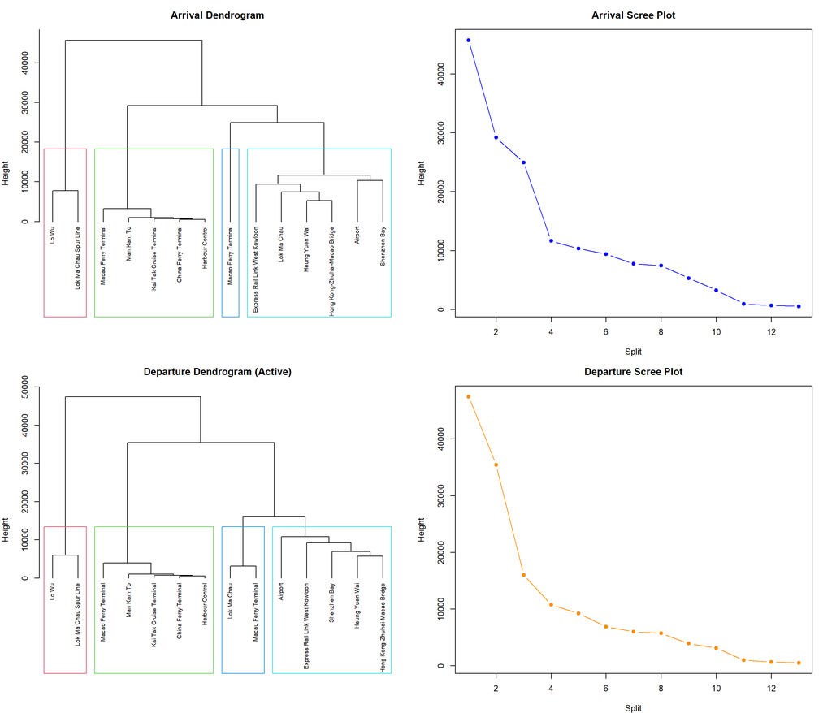

```r
library(tidyr)
library(ggplot2)
library(knitr)

# ==============================================================================
# PART 1: Raw Data Clustering Framework
# ==============================================================================

# 1.1 Ingestion
traffic_raw <- read_csv("statistics_on_daily_passenger_traffic.csv",
                        col_types = cols(Date = col_date(format = "%d/%m/%Y")))
colnames(traffic_raw) <- gsub("[^[:alnum:]]+", "_", tolower(colnames(traffic_raw)))
traffic_raw <- traffic_raw %>% mutate(date = as.Date(date))

# 1.2 Raw RMS Distance Function
compute_raw_rms_distance <- function(subset_data, points) {
  n <- length(points)
  d <- matrix(0, n, n, dimnames = list(points, points))

  for(i in 1:(n-1)) {
    for(j in (i+1):n) {
      cp_i <- subset_data %>% filter(control_point == points[i])
      cp_j <- subset_data %>% filter(control_point == points[j])
      p <- inner_join(cp_i, cp_j, by="date", suffix=c("_i", "_j"))

      if(nrow(p) > 5) {
        val <- sqrt(mean(((p$hong_kong_residents_i - p$hong_kong_residents_j)^2 +
                          (p$mainland_visitors_i - p$mainland_visitors_j)^2 +
                          (p$other_visitors_i - p$other_visitors_j)^2) / 3))
        d[i,j] <- d[j,i] <- val
      }
    }
  }
  max_val <- max(d, na.rm = TRUE)
  d[d==0 & row(d) != col(d)] <- max_val
  return(as.dist(d))
}

# 1.3 Clustered Analysis Wrapper
perform_clustered_analysis <- function(data, direction) {
  subset_data <- data %>% filter(arrival_departure == direction)

  cp_means <- subset_data %>% group_by(control_point) %>% summarize(m = mean(total, na.rm = TRUE))
  irrelevant_pts <- cp_means %>% filter(m == 0) %>% pull(control_point)
  active_pts <- cp_means %>% filter(m > 0) %>% pull(control_point)

  # Clustering Active Points
  dist_mat <- compute_raw_rms_distance(subset_data %>% filter(control_point %in% active_pts), active_pts)
  hclust_obj <- hclust(dist_mat, method = "ward.D2")
  cuts <- cutree(hclust_obj, k = 4)

  # Ranking and Labeling
  rank_map <- data.frame(control_point = names(cuts), active_clust = as.numeric(cuts)) %>%
    inner_join(subset_data %>% group_by(control_point) %>% summarize(mv = mean(total, na.rm = TRUE)), by = "control_point") %>%
    group_by(active_clust) %>%
    summarize(gm = mean(mv)) %>%
    arrange(desc(gm)) %>%
    mutate(category = c("Main", "Sub", "Low", "Irrelevant"))

  assignments <- data.frame(control_point = names(cuts), active_clust = as.numeric(cuts)) %>%
    inner_join(rank_map, by = "active_clust") %>%
    select(control_point, category) %>%
    rbind(data.frame(control_point = irrelevant_pts, category = "Irrelevant"))

  return(list(hclust = hclust_obj, assignments = assignments))
}

# 1.4 Execution
arr_res <- perform_clustered_analysis(traffic_raw, "Arrival")
dep_res <- perform_clustered_analysis(traffic_raw, "Departure")

# ===========================================================================
# PART 2: Visualizations & Reporting
# ==============================================================================

par(mfrow = c(2, 2), mar = c(4, 4, 3, 2))

# Dendrograms & Scree Plots
plot(arr_res$hclust, main="Arrival Dendrogram", sub="", xlab="", hang=-1, cex=0.7)
rect.hclust(arr_res$hclust, k=4, border=2:5)
plot(rev(arr_res$hclust$height), type="b", pch=19, col="blue", main="Arrival Scree Plot", ylab="Height", xlab="Split")

plot(dep_res$hclust, main="Departure Dendrogram (Active)", sub="", xlab="", hang=-1, cex=0.7)
rect.hclust(dep_res$hclust, k=4, border=2:5)
plot(rev(dep_res$hclust$height), type="b", pch=19, col="darkorange", main="Departure Scree Plot", ylab="Height", xlab="Split")
```

```r
# ------------------------------------------------------------------------------
# Control Point Level Cluster Comparison Table
# ------------------------------------------------------------------------------

# Compute individual control point means per direction
cp_mean_arrival <- traffic_raw %>%
  filter(arrival_departure == "Arrival") %>%
  group_by(control_point) %>%
  summarize(cp_mean_arr = mean(total, na.rm = TRUE), .groups = "drop")

cp_mean_departure <- traffic_raw %>%
  filter(arrival_departure == "Departure") %>%
  group_by(control_point) %>%
  summarize(cp_mean_dep = mean(total, na.rm = TRUE), .groups = "drop")

# Build base mapping data frame
detailed_mapping <- data.frame(control_point = unique(traffic_raw$control_point)) %>%
  left_join(arr_res$assignments %>% rename(cluster_arr = category), by = "control_point") %>%
  left_join(dep_res$assignments %>% rename(cluster_dep = category), by = "control_point") %>%
  left_join(cp_mean_arrival, by = "control_point") %>%
  left_join(cp_mean_departure, by = "control_point") %>%
  mutate(
    cluster_arr = ifelse(is.na(cluster_arr), "Irrelevant", cluster_arr),
    cluster_dep = ifelse(is.na(cluster_dep), "Irrelevant", cluster_dep),
    cp_mean_arr = ifelse(is.na(cp_mean_arr), 0, cp_mean_arr),
    cp_mean_dep = ifelse(is.na(cp_mean_dep), 0, cp_mean_dep)
  )

# Compute corresponding cluster group level means
cluster_mean_arrival <- detailed_mapping %>%
  group_by(cluster_arr) %>%
  summarize(group_mean_arr = mean(cp_mean_arr), .groups = "drop")

cluster_mean_departure <- detailed_mapping %>%
  group_by(cluster_dep) %>%
  summarize(group_mean_dep = mean(cp_mean_dep), .groups = "drop")

# Assemble the final requested display layout
display_table <- detailed_mapping %>%
  left_join(cluster_mean_arrival, by = "cluster_arr") %>%
  left_join(cluster_mean_departure, by = "cluster_dep") %>%
  select(
    `Control point` = control_point,
    `Cluster group name in Arrival` = cluster_arr,
    `Cluster group name in Departure` = cluster_dep,
    `mean of control point in Arrival` = cp_mean_arr,
    `mean of cluster group in Arrival` = group_mean_arr,
    `mean of control point in Departure` = cp_mean_dep,
    `mean of cluster group in Departure` = group_mean_dep
  ) %>%
  arrange(desc(`mean of control point in Arrival`))

print(kable(display_table, digits = 2, caption = "Control Point Cluster Group Assignment and Mean Comparison"))
```

```
##
##
## Table: Control Point Cluster Group Assignment and Mean Comparison
##
## |Control point                  |Cluster group name in Arrival |Cluster group name in Departure | mean of control point in Arrival| mean of cluster group in Arrival| mean of control point in Departure| mean of cluster group in Departure|
## |:------------------------------|:-----------------------------|:-------------------------------|--------------------------------:|--------------------------------:|----------------------------------:|----------------------------------:|
## |Lo Wu                          |Main                          |Main                            |                         52310.87|                         48592.48|                           53700.90|                           50004.94|
## |Lok Ma Chau Spur Line          |Main                          |Main                            |                         44874.08|                         48592.48|                           46308.97|                           50004.94|
## |Airport                        |Sub                           |Sub                             |                         36397.80|                         24362.74|                           35643.99|                           26638.89|
## |Shenzhen Bay                   |Sub                           |Sub                             |                         31627.96|                         24362.74|                           30921.27|                           26638.89|
## |Express Rail Link West Kowloon |Sub                           |Sub                             |                         23595.85|                         24362.74|                           22272.73|                           26638.89|
## |Hong Kong-Zhuhai-Macao Bridge  |Sub                           |Sub                             |                         22570.01|                         24362.74|                           25113.54|                           26638.89|
## |Heung Yuen Wai                 |Sub                           |Sub                             |                         21297.58|                         24362.74|                           19242.92|                           26638.89|
## |Lok Ma Chau                    |Sub                           |Low                             |                         10687.27|                         24362.74|                            9797.33|                            7799.05|
## |Macao Ferry Terminal           |Low                           |Irrelevant                      |                          9086.36|                          9086.36|                            9536.94|                            1553.76|
## |Macau Ferry Terminal           |Irrelevant                    |Low                             |                          5374.47|                          1042.39|                            5800.77|                            7799.05|
## |Man Kam To                     |Irrelevant                    |Irrelevant                      |                          1445.26|                          1042.39|                            1395.35|                            1553.76|
## |China Ferry Terminal           |Irrelevant                    |Irrelevant                      |                           904.93|                          1042.39|                             884.81|                            1553.76|
## |Kai Tak Cruise Terminal        |Irrelevant                    |Irrelevant                      |                           583.74|                          1042.39|                             585.86|                            1553.76|
## |Harbour Control                |Irrelevant                    |Irrelevant                      |                            30.75|                          1042.39|                              27.15|                            1553.76|
## |Hung Hom                       |Irrelevant                    |Irrelevant                      |                             0.00|                          1042.39|                               0.00|                            1553.76|
## |Sha Tau Kok                    |Irrelevant                    |Irrelevant                      |                             0.00|                          1042.39|                               0.00|                            1553.76|
## |Tuen Mun Ferry Terminal        |Irrelevant                    |Irrelevant                      |                             0.00|                          1042.39|                               0.00|                            1553.76|
```

```r
# ==============================================================================
# PART 3: Final Aggregation
# ==============================================================================

master_mapping <- bind_rows(
  arr_res$assignments %>% mutate(arrival_departure = "Arrival"),
  dep_res$assignments %>% mutate(arrival_departure = "Departure")
)

df_aggregated <- traffic_raw %>%
  left_join(master_mapping, by = c("control_point", "arrival_departure")) %>%
  filter(!is.na(category)) %>%
  group_by(category, arrival_departure, date) %>%
  summarise(
    hong_kong_residents = sum(hong_kong_residents, na.rm = TRUE),
    mainland_visitors   = sum(mainland_visitors, na.rm = TRUE),
    other_visitors      = sum(other_visitors, na.rm = TRUE),
    .groups = "drop"
  ) %>%
  mutate(weekday = as.factor(weekdays(date)),
         policy_factor = as.factor(ifelse(date < as.Date("2022-12-14"), "Pre", "Post")))
```

### Clustering result and analysis

```r
# ------------------------------------------------------------------------------
# New Control Point Level Cluster Comparison Table(With 'Lower' Class Consolidation)
# ------------------------------------------------------------------------------

# 1. Define the specific control points to override
manual_lower_points <- c("Lok Ma Chau", "Macau Ferry Terminal", "Macao Ferry Terminal")

# Compute individual control point means per direction
cp_mean_arrival <- traffic_raw %>%
  filter(arrival_departure == "Arrival") %>%
  group_by(control_point) %>%
  summarize(cp_mean_arr = mean(total, na.rm = TRUE), .groups = "drop")

cp_mean_departure <- traffic_raw %>%
  filter(arrival_departure == "Departure") %>%
  group_by(control_point) %>%
  summarize(cp_mean_dep = mean(total, na.rm = TRUE), .groups = "drop")

# Build base mapping data frame and reclassify "Low" / "Irrelevant" to "Lower"
detailed_mapping <- data.frame(control_point = unique(traffic_raw$control_point)) %>%
  left_join(arr_res$assignments %>% rename(cluster_arr = category), by = "control_point") %>%
  left_join(dep_res$assignments %>% rename(cluster_dep = category), by = "control_point") %>%
  left_join(cp_mean_arrival, by = "control_point") %>%
  left_join(cp_mean_departure, by = "control_point") %>%
  mutate(
    # Handle implicit missing values before collapsing categories
    cluster_arr = ifelse(is.na(cluster_arr), "Irrelevant", cluster_arr),
    cluster_dep = ifelse(is.na(cluster_dep), "Irrelevant", cluster_dep),

    # Manual Override: Consolidate Low and Irrelevant into the unified "Lower" group
    cluster_arr = ifelse(control_point %in% manual_lower_points, "Lower", cluster_arr),
    cluster_dep = ifelse(control_point %in% manual_lower_points, "Lower", cluster_dep),

    cp_mean_arr = ifelse(is.na(cp_mean_arr), 0, cp_mean_arr),
    cp_mean_dep = ifelse(is.na(cp_mean_dep), 0, cp_mean_dep)
  )



# Compute corresponding cluster group level means using the updated "Lower" classification
cluster_mean_arrival <- detailed_mapping %>%
  group_by(cluster_arr) %>%
  summarize(group_mean_arr = mean(cp_mean_arr), .groups = "drop")

cluster_mean_departure <- detailed_mapping %>%
  group_by(cluster_dep) %>%
  summarize(group_mean_dep = mean(cp_mean_dep), .groups = "drop")

# Assemble the final requested display layout
display_table <- detailed_mapping %>%
  left_join(cluster_mean_arrival, by = "cluster_arr") %>%
  left_join(cluster_mean_departure, by = "cluster_dep") %>%
  select(
    `Control point` = control_point,
    `Cluster group name in Arrival` = cluster_arr,
    `Cluster group name in Departure` = cluster_dep,
    `mean of control point in Arrival` = cp_mean_arr,
    `mean of cluster group in Arrival` = group_mean_arr,
    `mean of control point in Departure` = cp_mean_dep,
    `mean of cluster group in Departure` = group_mean_dep
  ) %>%
  arrange(desc(`mean of control point in Arrival`))

print(kable(display_table, digits = 2, caption = "Final Control Point Cluster Group Assignment and Mean Comparison"))
```

```
##
##
## Table: Final Control Point Cluster Group Assignment and Mean Comparison
##
## |Control point                  |Cluster group name in Arrival |Cluster group name in Departure | mean of control point in Arrival| mean of cluster group in Arrival| mean of control point in Departure| mean of cluster group in Departure|
## |:------------------------------|:-----------------------------|:-------------------------------|--------------------------------:|--------------------------------:|----------------------------------:|----------------------------------:|
## |Lo Wu                          |Main                          |Main                            |                         52310.87|                         48592.48|                           53700.90|                           50004.94|
## |Lok Ma Chau Spur Line          |Main                          |Main                            |                         44874.08|                         48592.48|                           46308.97|                           50004.94|
## |Airport                        |Sub                           |Sub                             |                         36397.80|                         27097.84|                           35643.99|                           26638.89|
## |Shenzhen Bay                   |Sub                           |Sub                             |                         31627.96|                         27097.84|                           30921.27|                           26638.89|
## |Express Rail Link West Kowloon |Sub                           |Sub                             |                         23595.85|                         27097.84|                           22272.73|                           26638.89|
## |Hong Kong-Zhuhai-Macao Bridge  |Sub                           |Sub                             |                         22570.01|                         27097.84|                           25113.54|                           26638.89|
## |Heung Yuen Wai                 |Sub                           |Sub                             |                         21297.58|                         27097.84|                           19242.92|                           26638.89|
## |Lok Ma Chau                    |Lower                         |Lower                           |                         10687.27|                          8382.70|                            9797.33|                            8378.35|
## |Macao Ferry Terminal           |Lower                         |Lower                           |                          9086.36|                          8382.70|                            9536.94|                            8378.35|
## |Macau Ferry Terminal           |Lower                         |Lower                           |                          5374.47|                          8382.70|                            5800.77|                            8378.35|
## |Man Kam To                     |Irrelevant                    |Irrelevant                      |                          1445.26|                           423.52|                            1395.35|                             413.31|
## |China Ferry Terminal           |Irrelevant                    |Irrelevant                      |                           904.93|                           423.52|                             884.81|                             413.31|
## |Kai Tak Cruise Terminal        |Irrelevant                    |Irrelevant                      |                           583.74|                           423.52|                             585.86|                             413.31|
## |Harbour Control                |Irrelevant                    |Irrelevant                      |                            30.75|                           423.52|                              27.15|                             413.31|
## |Hung Hom                       |Irrelevant                    |Irrelevant                      |                             0.00|                           423.52|                               0.00|                             413.31|
## |Sha Tau Kok                    |Irrelevant                    |Irrelevant                      |                             0.00|                           423.52|                               0.00|                             413.31|
## |Tuen Mun Ferry Terminal        |Irrelevant                    |Irrelevant                      |                             0.00|                           423.52|                               0.00|                             413.31|
```

```r
# ==============================================================================
# PART 3: Final Aggregation (Separation of Concerns)
# ==============================================================================

# 1. Standard Mapping Preparation
master_mapping <- bind_rows(
  arr_res$assignments %>% mutate(arrival_departure = "Arrival"),
  dep_res$assignments %>% mutate(arrival_departure = "Departure")
) %>%
  mutate(category = ifelse(category %in% c("Low", "Irrelevant"), "Lower", category)) %>%
  mutate(category = ifelse(control_point %in% manual_lower_points, "Lower", category))

# 2. Aggregation for Time-Series Modeling (Clustered by Date)
df_aggregated <- traffic_raw %>%
  left_join(master_mapping, by = c("control_point", "arrival_departure")) %>%
  filter(!is.na(category)) %>%
  group_by(category, arrival_departure, date) %>%
  summarise(
    hong_kong_residents = sum(hong_kong_residents, na.rm = TRUE),
    mainland_visitors   = sum(mainland_visitors, na.rm = TRUE),
    other_visitors      = sum(other_visitors, na.rm = TRUE),
    .groups = "drop"
  ) %>%
  mutate(
    weekday = as.factor(weekdays(date)),
    policy_factor = as.factor(ifelse(date < as.Date("2022-12-14"), "Pre", "Post"))
  )

# 3. Calculation of Weights (Calculated from Raw Data, NOT df_aggregated)
# This retains control_point granularity before summarization
cp_weights <- traffic_raw %>%
  left_join(master_mapping, by = c("control_point", "arrival_departure")) %>%
  filter(!is.na(category)) %>%
  group_by(category, arrival_departure, control_point) %>%
  summarise(
    cp_tot_hk = sum(hong_kong_residents, na.rm = TRUE),
    cp_tot_ml = sum(mainland_visitors, na.rm = TRUE),
    cp_tot_ot = sum(other_visitors, na.rm = TRUE),
    .groups = "drop"
  ) %>%
  group_by(category, arrival_departure) %>%
  mutate(
    cluster_tot_hk = sum(cp_tot_hk),
    cluster_tot_ml = sum(cp_tot_ml),
    cluster_tot_ot = sum(cp_tot_ot)
  ) %>%
  ungroup() %>%
  mutate(
    weight_hong_kong_residents = ifelse(cluster_tot_hk > 0, cp_tot_hk / cluster_tot_hk, 0),
    weight_mainland_visitors   = ifelse(cluster_tot_ml > 0, cp_tot_ml / cluster_tot_ml, 0),
    weight_other_visitors      = ifelse(cluster_tot_ot > 0, cp_tot_ot / cluster_tot_ot, 0)
  ) %>%
  select(category, arrival_departure, control_point,
         weight_hong_kong_residents, weight_mainland_visitors, weight_other_visitors)
```

## Part 2: Hierarchical Model Fitting & Unified Component Visualization

After combining the control points into 3 patterns, we can start to model the time-series data for Arrival and Departure separately. To understand the cyclical behaviors of border crossings at Hong Kong control points, we first establish the mathematical framework of the data. The provided visual outputs represent the isolated annual seasonal component, denoted as $\hat{S}_t^{(365)}$, extracted via a Multi-Seasonal Trend Decomposition using LOESS (MSTL). The full structural time series model is formalized as:

$Y_t = T_t + S_t^{(7)} + S_t^{(365)} + R_t$

where $Y_t$ is the observed daily passenger volume, $T_t$ represents the long-term trend, $S_t^{(7)}$ captures the high-frequency weekly cyclical variations, $\hat{S}_t^{(365)}$ isolates the annual seasonal innovations, and $R_t$ is the stochastic remainder layer. To further reduce the error, we conduct two fittings on $R_t$ as well, using Linear Regression (LR) and Seasonal Auto-Regressive Integrated Moving Average with Exogenous Regressors (SARIMAX), so that we can check whether the policy effects, weekday effects, or serial correlation effects remain and include them to reduce the final error.

```
##
## ### MSTL Decomposition Matrix:  Main | Arrival | hong_kong_residents
```

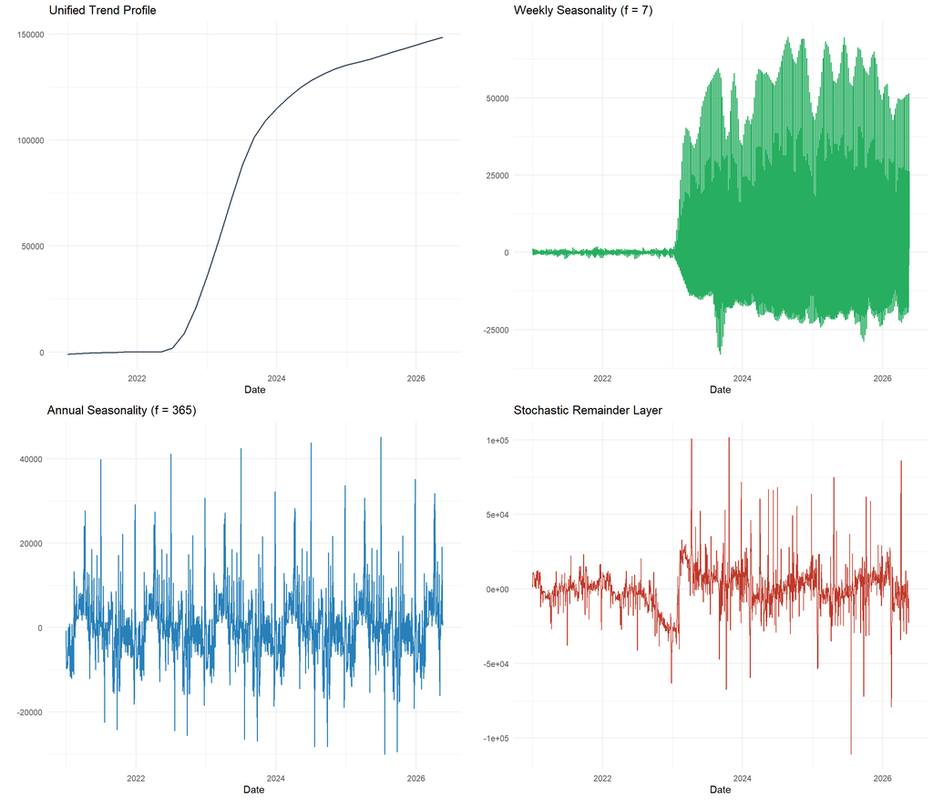

```
##
## ### MSTL Decomposition Matrix:  Sub | Arrival | hong_kong_residents
```

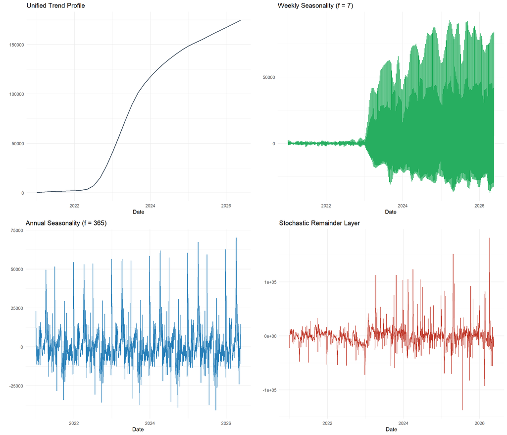

```
##
## ### MSTL Decomposition Matrix:  Main | Departure | hong_kong_residents
```

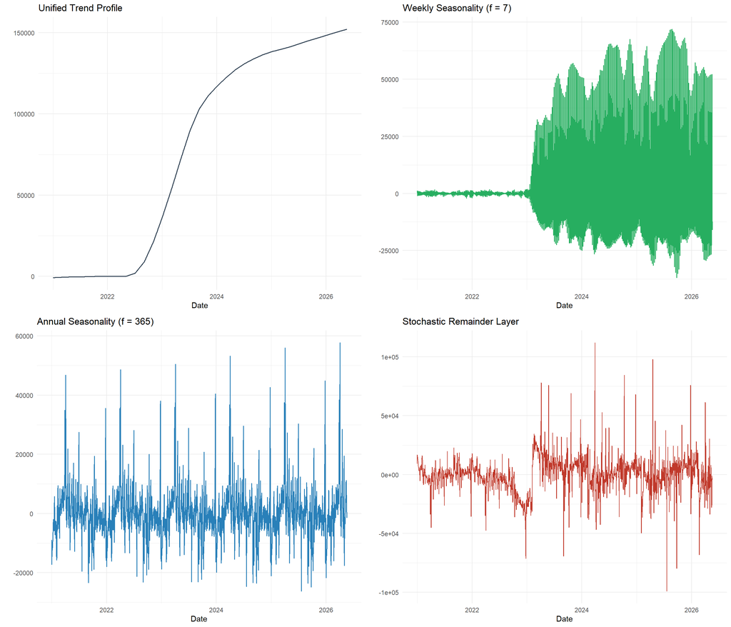

```
##
## ### MSTL Decomposition Matrix:  Sub | Departure | hong_kong_residents
```

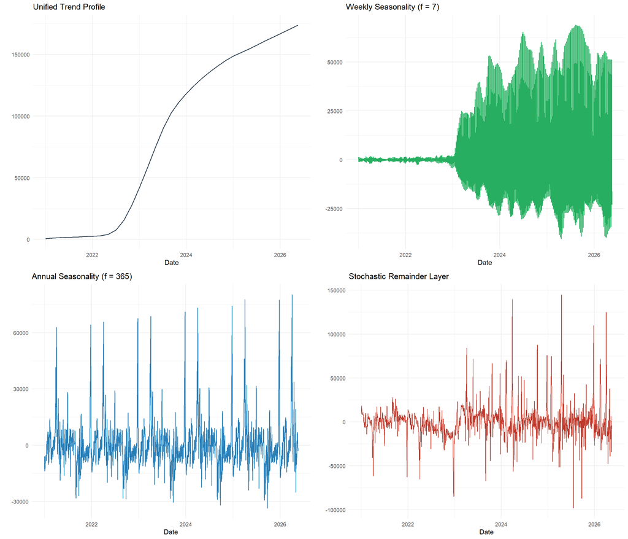

```
##
## ### MSTL Decomposition Matrix:  Main | Arrival | mainland_visitors
```

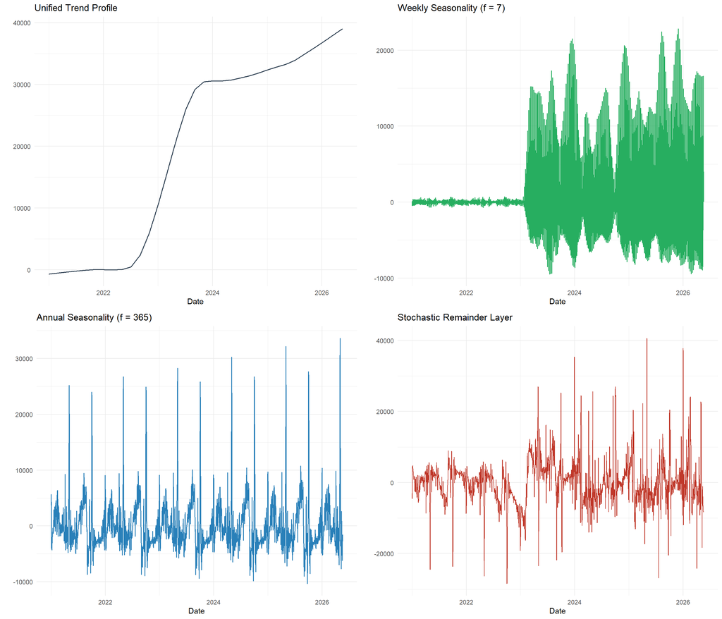

```
##
## ### MSTL Decomposition Matrix:  Sub | Arrival | mainland_visitors
```

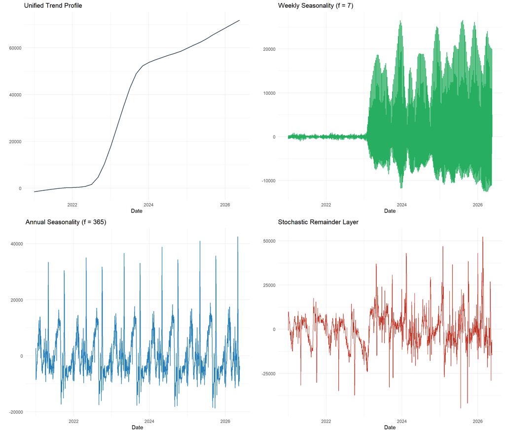

```
##
## ### MSTL Decomposition Matrix:  Main | Departure | mainland_visitors
```

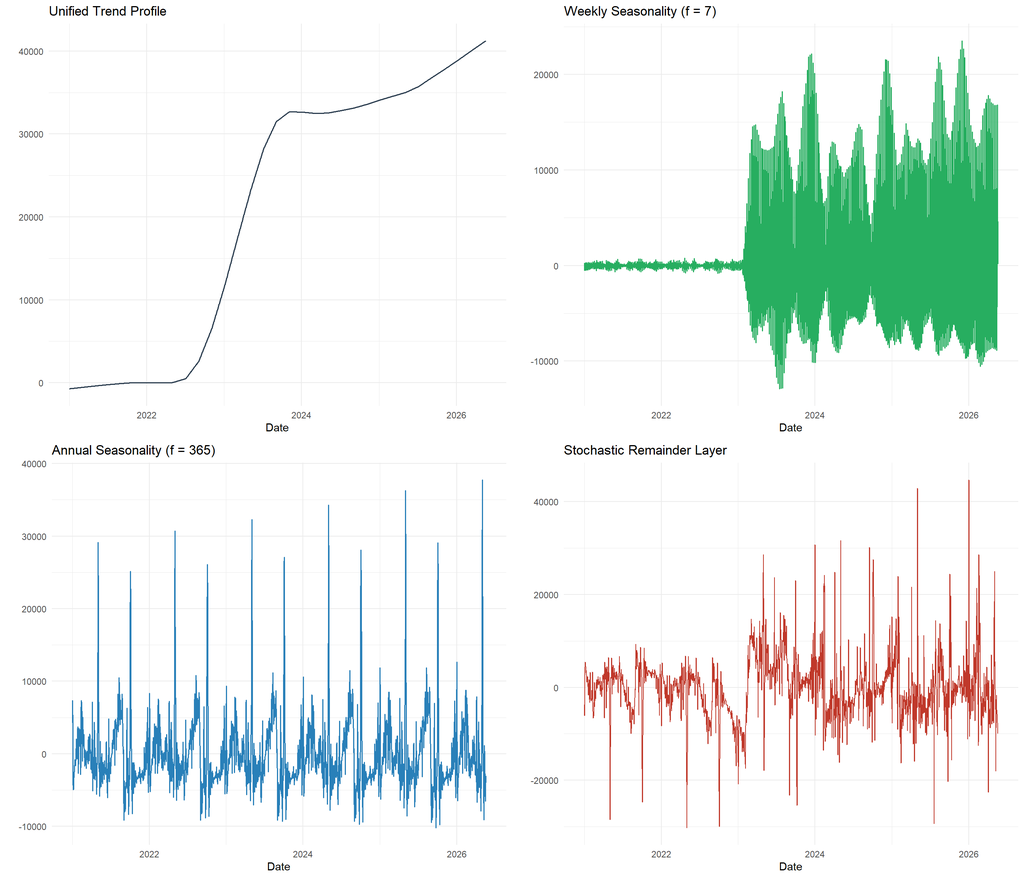

```
##
## ### MSTL Decomposition Matrix:  Sub | Departure | mainland_visitors
```

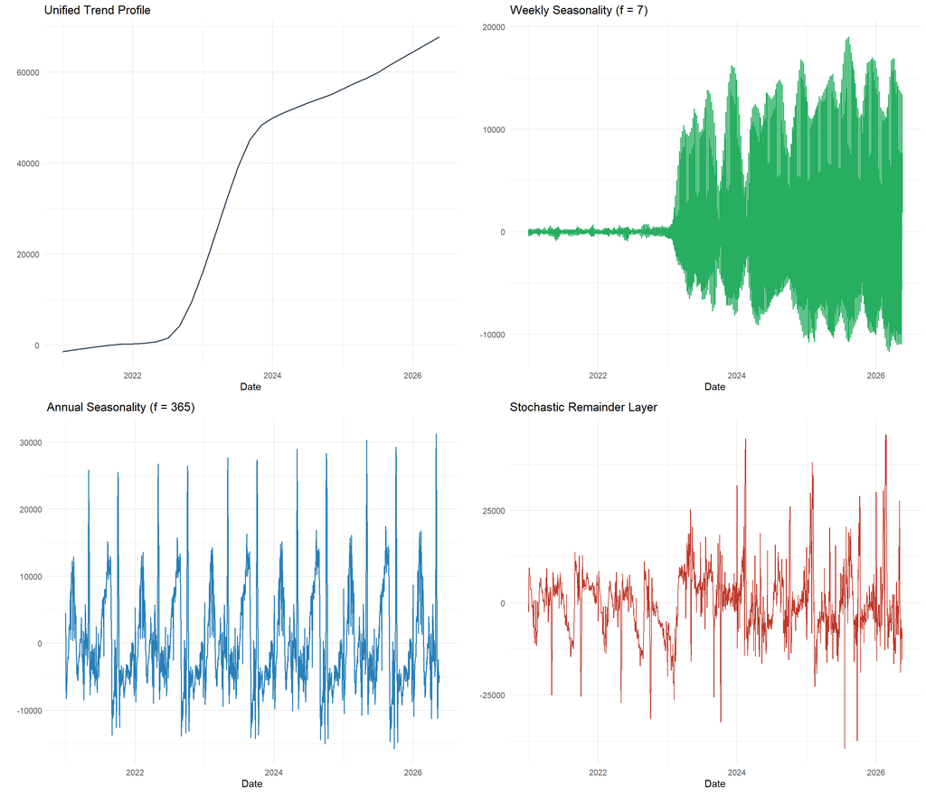

```
##
## ### MSTL Decomposition Matrix:  Main | Arrival | other_visitors
```

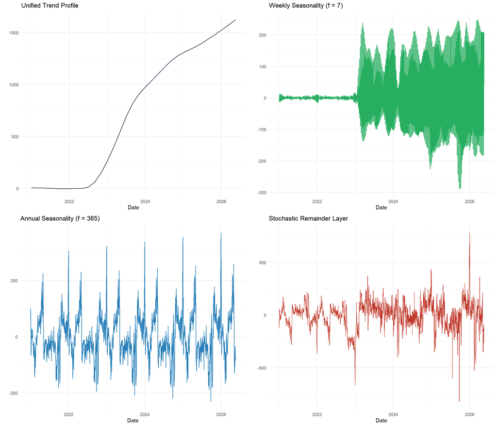

```
##
## ### MSTL Decomposition Matrix:  Sub | Arrival | other_visitors
```

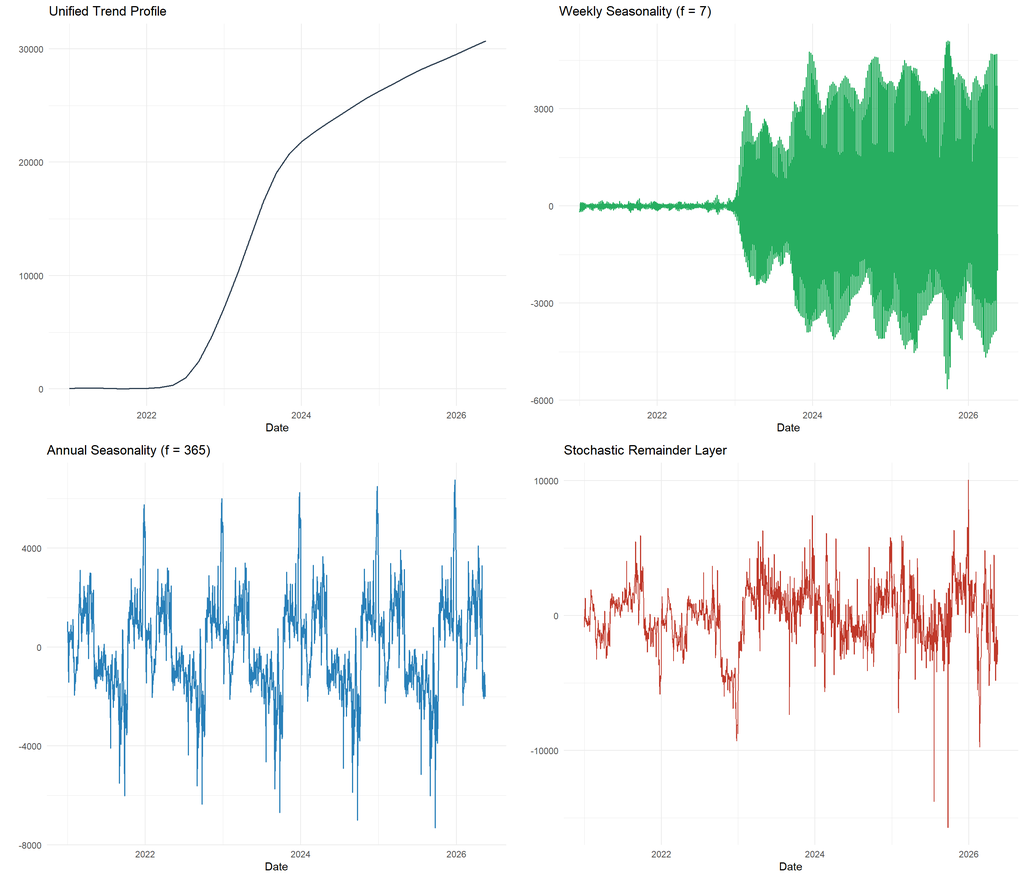

```
##
## ### MSTL Decomposition Matrix:  Main | Departure | other_visitors
```

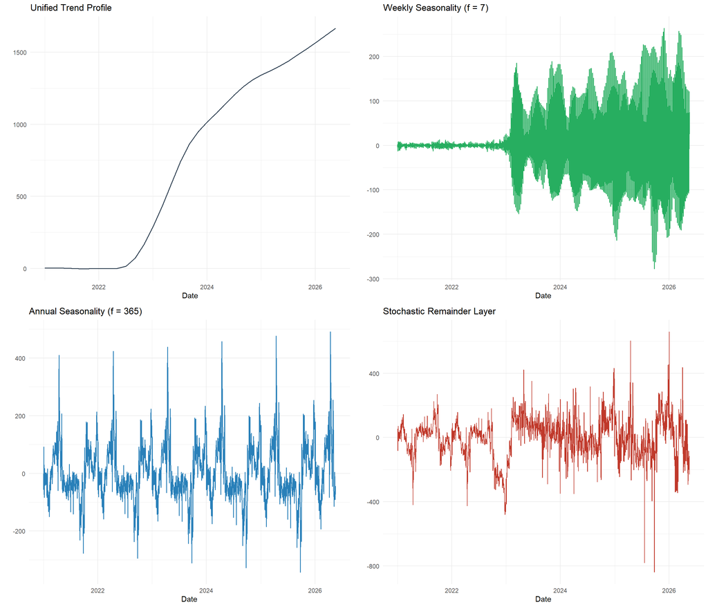

```
##
## ### MSTL Decomposition Matrix:  Sub | Departure | other_visitors
```

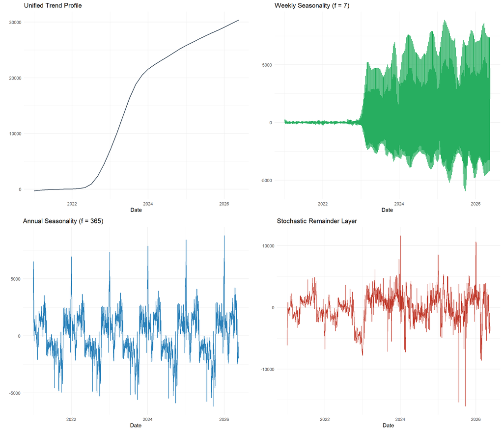

```r
library(forecast)
library(ggplot2)
library(gridExtra)
library(dplyr)
library(knitr)

# Initialize consolidated multi-framework logs
performance_metrics_log  <- list()
residual_diagnostic_log  <- list()
lm_significant_summaries <- list()
persistent_model_store   <- list()

categories    <- c("Main", "Sub", "Low")
ad_types      <- unique(df_aggregated$arrival_departure)
visitor_types <- c("hong_kong_residents", "mainland_visitors", "other_visitors")

for (v_type in visitor_types) {
  for (ad in ad_types) {
    for (cat in categories) {

      subset_data <- df_aggregated %>%
        filter(category == cat, arrival_departure == ad) %>%
        arrange(date)

      if(nrow(subset_data) == 0) next

      n_obs <- nrow(subset_data)
      Y_t   <- as.numeric(subset_data[[v_type]])
      combo_label <- sprintf("%s | %s | %s", cat, ad, v_type)

      # ========================================================================
      # SYSTEM REFACTOR: UNIFIED MULTI-FRAMEWORK SEASONAL DECOMPOSITION (MSTL)
      # ========================================================================
      if (n_obs >= 730) {
        # High Strata: Complete Joint Estimation (Weekly (7) + Annual (365) Cycles)
        ts_multi <- msts(Y_t, seasonal.periods = c(7, 365))
        MSTL_fit <- mstl(ts_multi)
      } else if (n_obs >= 14) {
        # Intermediate Strata: Isolated Weekly Cycle Estimation
        ts_multi <- msts(Y_t, seasonal.periods = c(7))
        MSTL_fit <- mstl(ts_multi)
      } else {
        # Low Strata Fallback: Non-parametric Local Polynomial Smoother
        trend_final  <- as.numeric(lowess(Y_t, f = 2/3)$y)
        seasonal_7   <- rep(0, n_obs)
        seasonal_365 <- rep(0, n_obs)
        r2           <- Y_t - trend_final
        # Skip to plotting
        next
      }

      # DYNAMIC MSTL EXTRACTION (Fixes Subscript Error)
      cnames <- colnames(MSTL_fit)
      trend_final  <- as.numeric(MSTL_fit[, "Trend"])
      seas_indices <- grep("Seasonal", cnames)

      if (length(seas_indices) >= 2) {
        seasonal_7   <- as.numeric(MSTL_fit[, seas_indices[1]])
        seasonal_365 <- as.numeric(MSTL_fit[, seas_indices[2]])
      } else if (length(seas_indices) == 1) {
        seasonal_7   <- as.numeric(MSTL_fit[, seas_indices[1]])
        seasonal_365 <- rep(0, n_obs)
      } else {
        seasonal_7   <- rep(0, n_obs)
        seasonal_365 <- rep(0, n_obs)
      }
      r2 <- as.numeric(MSTL_fit[, "Remainder"])

      # ========================================================================
      # SIMPLIFIED STRUCTURAL DIAGNOSTIC PANEL ASSEMBLY
      # ========================================================================
      plot_df <- data.frame(
        Date        = subset_data$date,
        Trend       = trend_final,
        Seasonal7   = seasonal_7,
        Seasonal365 = seasonal_365,
        Remainder   = r2
      )

      p1 <- ggplot(plot_df, aes(Date, Trend)) +
        geom_line(color="#2c3e50", size=0.7) +
        labs(title="Unified Trend Profile", y="") + theme_minimal()

      p2 <- ggplot(plot_df, aes(Date, Seasonal7)) +
        geom_line(color="#27ae60", size=0.7) +
        labs(title="Weekly Seasonality (f = 7)", y="") + theme_minimal()

      p3 <- ggplot(plot_df, aes(Date, Seasonal365)) +
        geom_line(color="#2980b9", size=0.7) +
        labs(title="Annual Seasonality (f = 365)", y="") + theme_minimal()

      p4 <- ggplot(plot_df, aes(Date, Remainder)) +
        geom_line(color="#c0392b", size=0.5) +
        labs(title="Stochastic Remainder Layer", y="") + theme_minimal()

      cat("\n### MSTL Decomposition Matrix: ", combo_label, "\n")
      print(invisible(grid.arrange(p1, p2, p3, p4, ncol=2)))

      # ========================================================================
      # STOCHASTIC FILTERING & STRUCTURAL SPECIFICATION (ARIMAX & OLS)
      # ========================================================================
      full_xreg <- model.matrix(~ policy_factor * weekday, data = subset_data)[, -1]
      xreg_matrix <- full_xreg[, apply(full_xreg, 2, var, na.rm=TRUE) != 0, drop=FALSE]

      sarimax_fit <- tryCatch({
        auto.arima(ts(r2, frequency = 7), xreg = xreg_matrix, seasonal = T, stationary = TRUE, stepwise = T, approximation = T,
                  parallel = TRUE,   # 真正啟動平行運算
                  num.cores = 6,
    max.p = 7, max.q = 7,  # Reduces non-seasonal search space
    max.P = 3, max.Q = 3)
      }, error = function(e) NULL)

      sig_coeffs_arima <- data.frame()
      if(!is.null(sarimax_fit)) {
        coefs <- coef(sarimax_fit)
        var_mat <- tryCatch(vcov(sarimax_fit), error = function(e) NULL)

        if (!is.null(var_mat) && is.matrix(var_mat) && nrow(var_mat) == length(coefs)) {
          se <- sqrt(diag(var_mat))
          z  <- coefs / se
          p  <- 2 * (1 - pnorm(abs(z)))
          df_a <- data.frame(Estimate = coefs, `Std. Error` = se, `z value` = z, `Pr(>|z|)` = p, check.names = FALSE)
          sig_coeffs_arima <- df_a[df_a$`Pr(>|z|)` < 0.05, , drop = FALSE]
        }
      }

      lm_fit <- tryCatch({
        lm(r2 ~ policy_factor * weekday, data = subset_data)
      }, error = function(e) NULL)

      sig_coeffs_lr <- data.frame()
      if(!is.null(lm_fit)) {
        lm_summary <- summary(lm_fit)$coefficients
        sig_coeffs_lr <- lm_summary[lm_summary[, "Pr(>|t|)"] < 0.05, , drop = FALSE]
      }

      lm_significant_summaries[[combo_label]] <- list(arima = sig_coeffs_arima, lr = sig_coeffs_lr)

      # ========================================================================
      # DIMENSIONAL CONFORMANCE RECONSTRUCTION GUARANTEES
      # ========================================================================
      fitted_r2_arima <- if(!is.null(sarimax_fit)) as.numeric(fitted(sarimax_fit)) else rep(0, n_obs)
      if(length(fitted_r2_arima) != n_obs) fitted_r2_arima <- rep(0, n_obs)

      fitted_r2_lr <- if(!is.null(lm_fit)) as.numeric(fitted(lm_fit)) else rep(0, n_obs)
      if(length(fitted_r2_lr) != n_obs) fitted_r2_lr <- rep(0, n_obs)

      fitted_Y_t_arima <- trend_final + seasonal_7 + seasonal_365 + fitted_r2_arima
      fitted_Y_t_lr    <- trend_final + seasonal_7 + seasonal_365 + fitted_r2_lr

      residual_diagnostic_log[[combo_label]] <- list(
        date            = subset_data$date,
        actual          = Y_t,
        fitted_arima    = fitted_Y_t_arima,
        residuals_arima = Y_t - fitted_Y_t_arima,
        fitted_lr       = fitted_Y_t_lr,
        residuals_lr    = Y_t - fitted_Y_t_lr,
        metadata        = list(cat = cat, ad = ad, v_type = v_type)
      )
      # Just store the object, do not save to disk here
      persistent_model_store[[combo_label]] <- list(
        sarimax = sarimax_fit,
        lm = lm_fit,
        mstl = MSTL_fit,
        # IMPORTANT: If you want to use the lookup method from the previous step,
        # add your maps here:
        w_map = tapply(as.numeric(MSTL_fit[, "Seasonal7"]), weekdays(subset_data$date), mean),
        doy_map = tapply(as.numeric(MSTL_fit[, grep("Seasonal", colnames(MSTL_fit))[2]]),
                         as.numeric(format(subset_data$date, "%j")), mean)
      )
    } # end of v_type loop
  } # end of ad loop
} # end of cat loop
```

```r
# Save the final file once everything is processed
saveRDS(persistent_model_store, "models_backup.rds")
```

```
##
## ### MSTL Decomposition Matrix:  Main | Arrival | hong_kong_residents
```

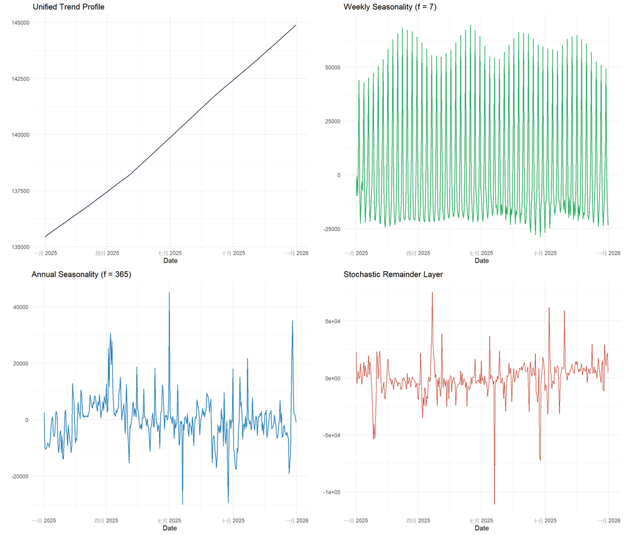

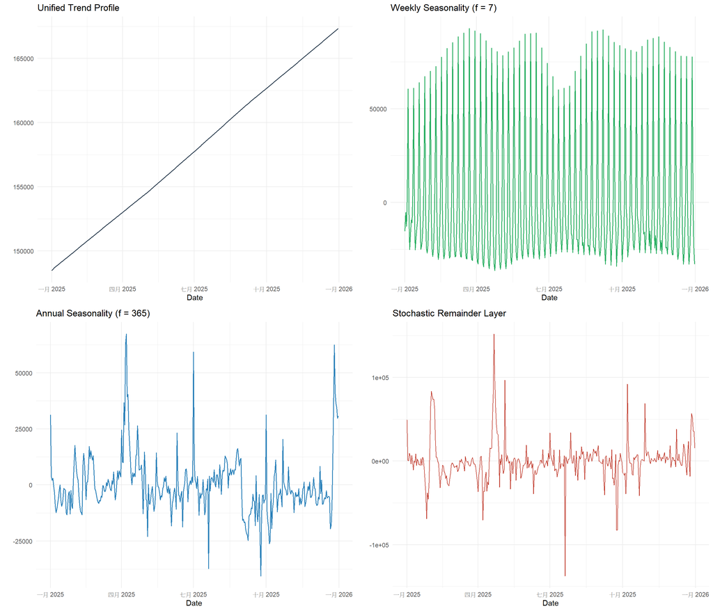

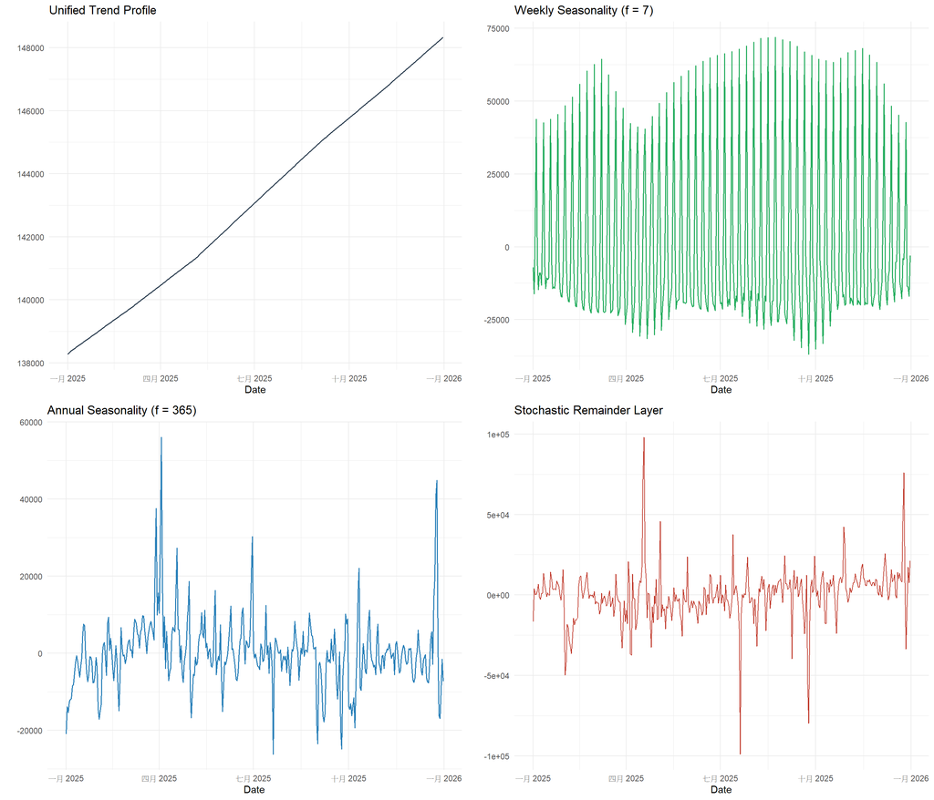

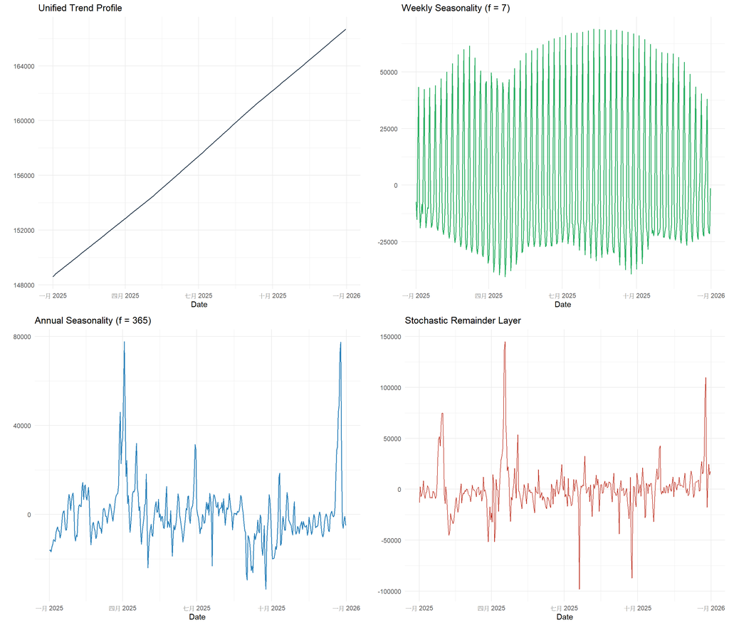

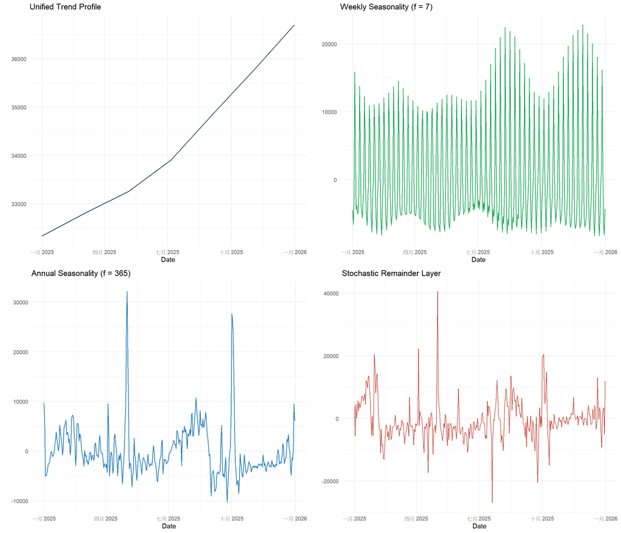

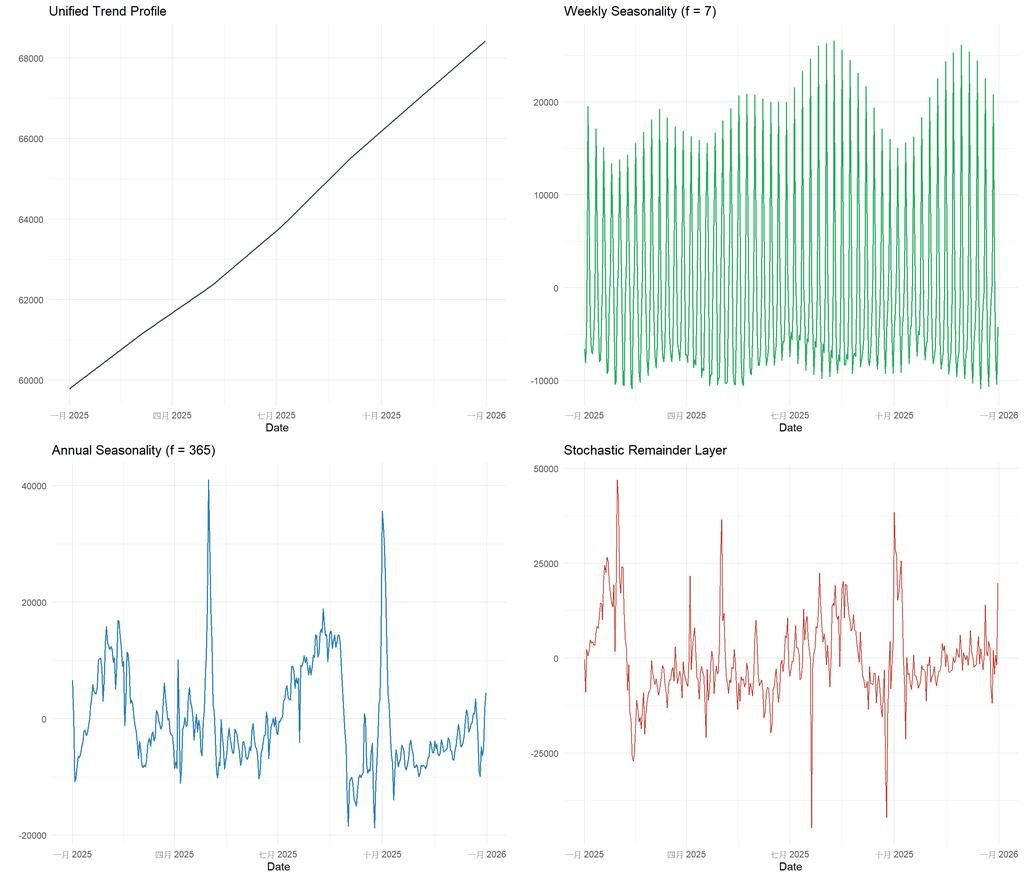

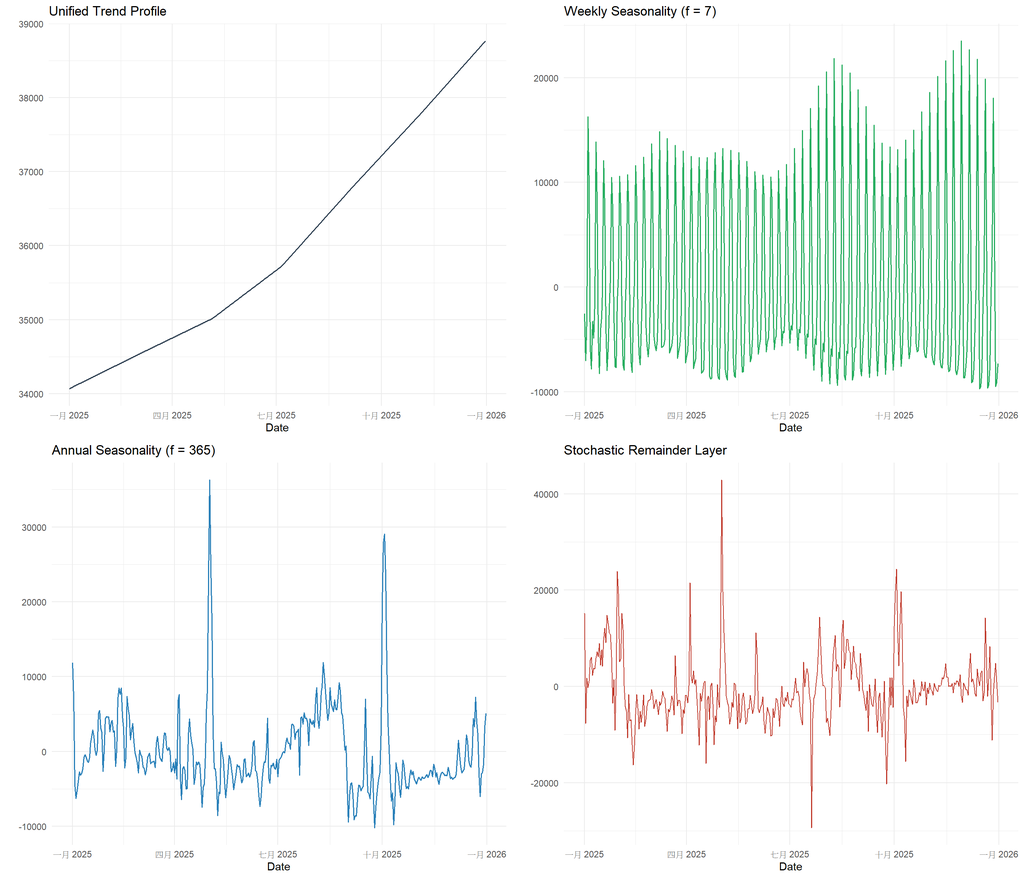

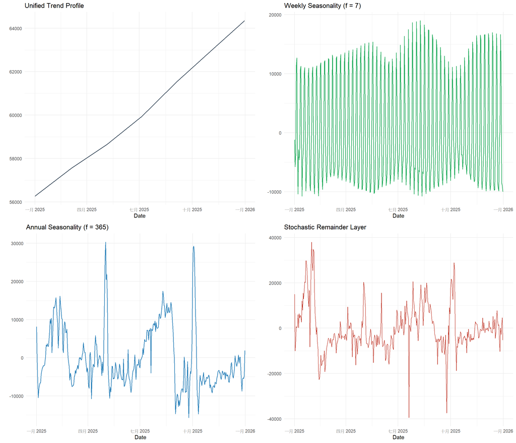

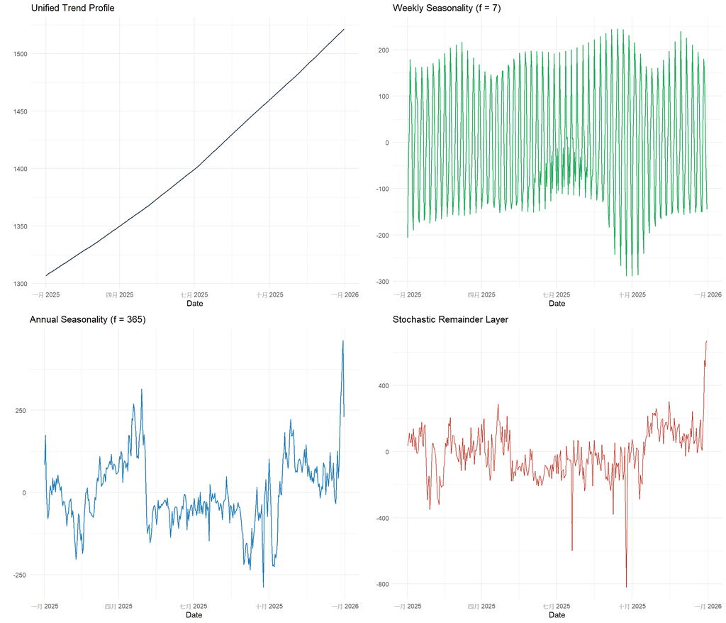

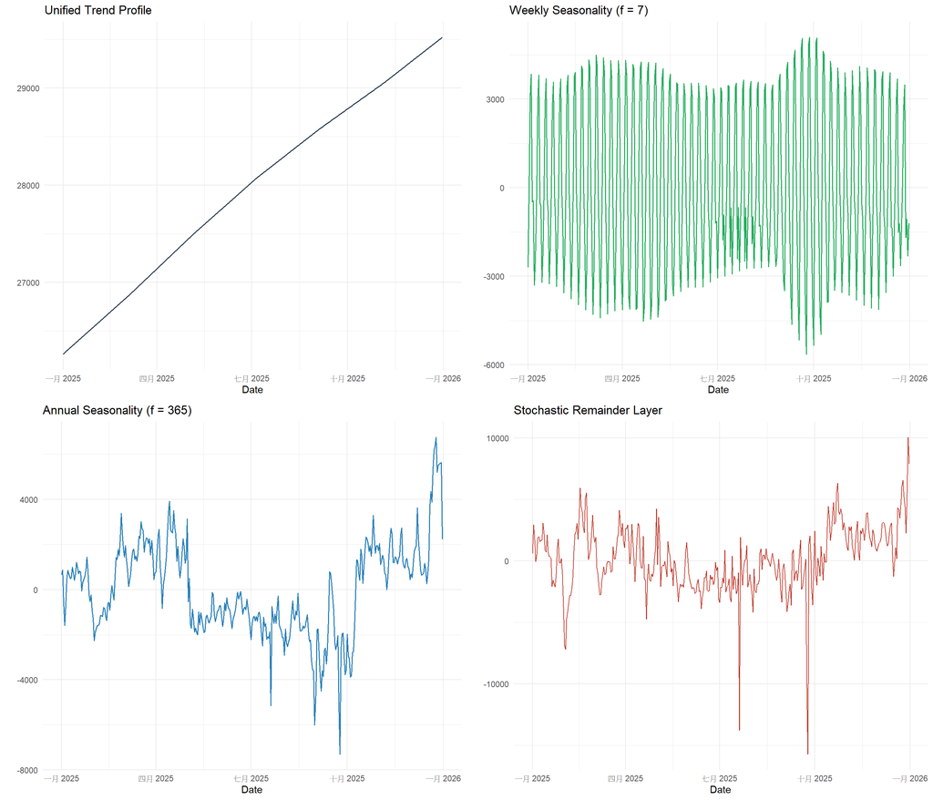

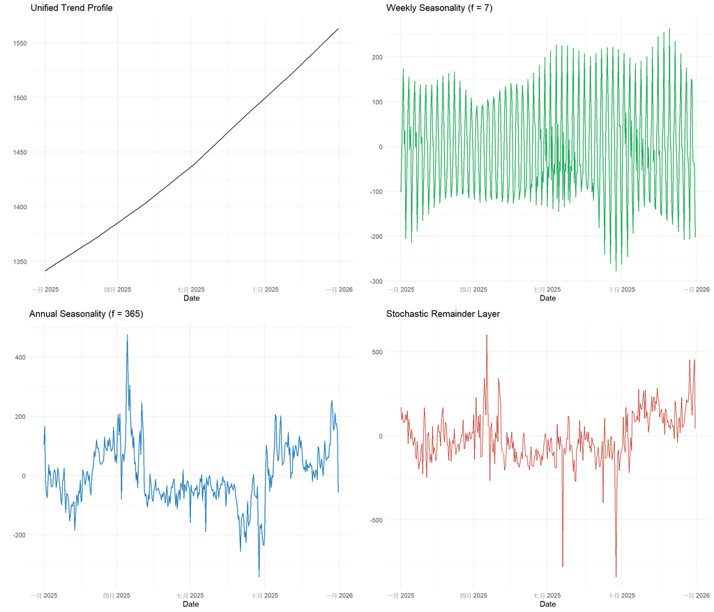

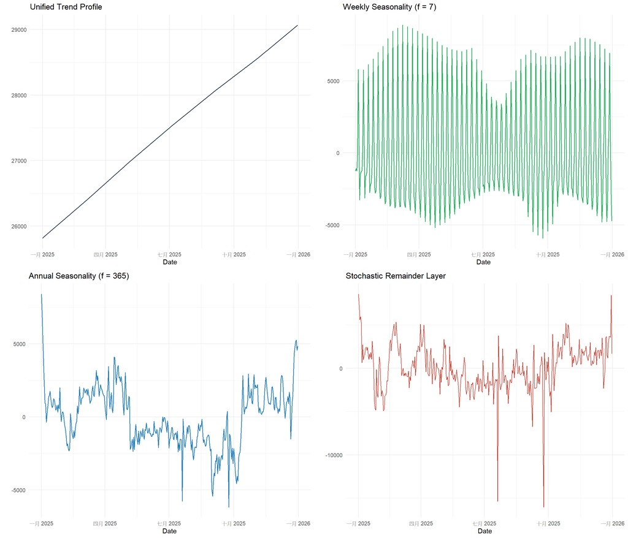

```r
library(forecast)
library(ggplot2)
library(gridExtra)
library(dplyr)
library(knitr)

categories    <- c("Main", "Sub")
ad_types      <- unique(df_aggregated$arrival_departure)
visitor_types <- c("hong_kong_residents", "mainland_visitors", "other_visitors")


for (v_type in visitor_types) {
  for (ad in ad_types) {
    for (cat in categories) {
      subset_data <- df_aggregated %>%
        filter(category == cat, arrival_departure == ad) %>%
        arrange(date)

      if(nrow(subset_data) == 0) next

      n_obs <- nrow(subset_data)
      Y_t   <- as.numeric(subset_data[[v_type]])
      combo_label <- sprintf("%s | %s | %s", cat, ad, v_type)


      if (n_obs >= 730) {
        # High Strata: Complete Joint Estimation (Weekly (7) + Annual (365) Cycles)
        ts_multi <- msts(Y_t, seasonal.periods = c(365, 7))
        MSTL_fit <- mstl(ts_multi)
      } else if (n_obs >= 14) {
        # Intermediate Strata: Isolated Weekly Cycle Estimation
        ts_multi <- msts(Y_t, seasonal.periods = c(7))
        MSTL_fit <- mstl(ts_multi)
      } else {
        # Low Strata Fallback: Non-parametric Local Polynomial Smoother
        trend_final  <- as.numeric(lowess(Y_t, f = 2/3)$y)
        seasonal_7   <- rep(0, n_obs)
        seasonal_365 <- rep(0, n_obs)
        r2           <- Y_t - trend_final
        # Skip to plotting
        next
      }

      # DYNAMIC MSTL EXTRACTION (Fixes Subscript Error)
      cnames <- colnames(MSTL_fit)
      trend_final  <- as.numeric(MSTL_fit[, "Trend"])
      seas_indices <- grep("Seasonal", cnames)

      if (length(seas_indices) >= 2) {
        seasonal_7   <- as.numeric(MSTL_fit[, seas_indices[1]])
        seasonal_365 <- as.numeric(MSTL_fit[, seas_indices[2]])
      } else if (length(seas_indices) == 1) {
        seasonal_7   <- as.numeric(MSTL_fit[, seas_indices[1]])
        seasonal_365 <- rep(0, n_obs)
      } else {
        seasonal_7   <- rep(0, n_obs)
        seasonal_365 <- rep(0, n_obs)
      }
      r2 <- as.numeric(MSTL_fit[, "Remainder"])

      plot_df <- data.frame(
        Date        = subset_data$date,
        Trend       = trend_final,
        Seasonal7   = seasonal_7,
        Seasonal365 = seasonal_365,
        Remainder   = r2
      )
      plot_df2025 <- subset(plot_df, format(Date, "%Y") == "2025")
      p1 <- ggplot(plot_df2025, aes(Date, Trend)) +
        geom_line(color="#2c3e50", size=0.7) +
        labs(title="Unified Trend Profile", y="") + theme_minimal()

      p2 <- ggplot(plot_df2025, aes(Date, Seasonal7)) +
        geom_line(color="#27ae60", size=0.7) +
        labs(title="Weekly Seasonality (f = 7)", y="") + theme_minimal()

      p3 <- ggplot(plot_df2025, aes(Date, Seasonal365)) +
        geom_line(color="#2980b9", size=0.7) +
        labs(title="Annual Seasonality (f = 365)", y="") + theme_minimal()

      p4 <- ggplot(plot_df2025, aes(Date, Remainder)) +
        geom_line(color="#c0392b", size=0.5) +
        labs(title="Stochastic Remainder Layer", y="") + theme_minimal()

      cat("\n### MSTL Decomposition Matrix: ", combo_label, "\n")
      print(invisible(grid.arrange(p1, p2, p3, p4, ncol=2)))
    } # end of v_type loop
  } # end of ad loop
} # end of cat loop
```

```r
# ========================================================================
# RENDER SIGNIFICANT MATRIX SUMMARIES
# ========================================================================
cat("\n# Statistical Summary: Significant Model Coefficients (p < 0.05)\n")
```

```
##
## # Statistical Summary: Significant Model Coefficients (p < 0.05)
```

```r
for (nm in names(lm_significant_summaries)) {
  cat("\n### Group Target Segment: ", nm, "\n")
  cat("\n#### MSTLSARIMAX Layer:\n")
  if (nrow(lm_significant_summaries[[nm]]$arima) > 0) {
    print(knitr::kable(lm_significant_summaries[[nm]]$arima, digits = 4, format = "markdown"))
  } else { cat("No significant stochastic filters.\n") }

  cat("\n#### MSTLLR Layer:\n")
  if (nrow(lm_significant_summaries[[nm]]$lr) > 0) {
    print(knitr::kable(lm_significant_summaries[[nm]]$lr, digits = 4, format = "markdown"))
  } else { cat("No significant structural parameters.\n") }
}
```

```
##
## ### Group Target Segment:  Main | Arrival | hong_kong_residents
##
## #### MSTLSARIMAX Layer:
##
##
## |     | Estimate| Std. Error|  z value| Pr(>&#124;z&#124;)|
## |:----|--------:|----------:|--------:|------------------:|
## |ar1  |   1.6262|     0.1817|   8.9489|             0.0000|
## |ar3  |  -0.6957|     0.3366|  -2.0670|             0.0387|
## |ar4  |   0.2359|     0.1182|   1.9961|             0.0459|
## |ar5  |  -0.1411|     0.0585|  -2.4097|             0.0160|
## |ar6  |   0.1388|     0.0327|   4.2462|             0.0000|
## |ma1  |  -1.0727|     0.1816|  -5.9065|             0.0000|
## |ma3  |   0.6157|     0.1566|   3.9314|             0.0001|
## |sar1 |  -0.3520|     0.0260| -13.5453|             0.0000|
## |sar2 |  -0.3488|     0.0242| -14.4087|             0.0000|
## |sar3 |  -0.1581|     0.0240|  -6.6000|             0.0000|
##
## #### MSTLLR Layer:
##
##
## |                 |  Estimate| Std. Error| t value| Pr(>&#124;t&#124;)|
## |:----------------|---------:|----------:|-------:|------------------:|
## |policy_factorPre | -4708.525|   1852.332| -2.5419|             0.0111|
##
## ### Group Target Segment:  Sub | Arrival | hong_kong_residents
##
## #### MSTLSARIMAX Layer:
##
##
## |     | Estimate| Std. Error|  z value| Pr(>&#124;z&#124;)|
## |:----|--------:|----------:|--------:|------------------:|
## |ar1  |   1.5168|     0.0719|  21.1092|             0.0000|
## |ar2  |  -0.5382|     0.0588|  -9.1458|             0.0000|
## |ar3  |   0.0867|     0.0412|   2.1025|             0.0355|
## |ar4  |  -0.0813|     0.0292|  -2.7859|             0.0053|
## |ma1  |  -0.8926|     0.0673| -13.2684|             0.0000|
## |sar1 |  -0.4107|     0.0241| -17.0400|             0.0000|
## |sar2 |  -0.3340|     0.0238| -14.0491|             0.0000|
```

[output cut: 192 more lines]

```
## |ar1  |   2.3919|     0.0520|  46.0144|                  0|
## |ar2  |  -1.8762|     0.0953| -19.6869|                  0|
## |ar3  |   0.4819|     0.0452|  10.6561|                  0|
## |ma1  |  -1.7437|     0.0415| -41.9777|                  0|
## |ma2  |   0.7951|     0.0392|  20.2940|                  0|
## |sar1 |  -0.3062|     0.0237| -12.9398|                  0|
## |sar2 |  -0.3462|     0.0225| -15.3533|                  0|
## |sar3 |  -0.2630|     0.0223| -11.7809|                  0|
##
## #### MSTLLR Layer:
##
##
## |                 |  Estimate| Std. Error| t value| Pr(>&#124;t&#124;)|
## |:----------------|---------:|----------:|-------:|------------------:|
## |policy_factorPre | -740.1931|   290.7515| -2.5458|              0.011|
```

### Analysis of MSTL result

#### General properties of MSTL

For the MSTL model, we observed the following global properties for daily passenger traffic:

- A significant increment in traffic activity after the Hong Kong government returned to normal epidemic prevention policies.
- A stationary increment in traffic activity for three types of travelers (Hong Kong residents, Mainland visitors, and overseas visitors). Interestingly, these three types of travelers show a similar trend in both arrival and departure.
- Each type has almost the same shape in both trend and seasonal effects between arrival and departure, with a short shift, indicating that short-period tourism or business trips are the most common types of traffic activities.
- Saturday and Sunday are the main days for people to enter and leave Hong Kong.

#### Hong Kong residents’ characteristics

The **first** significant **positive innovation** occurs in **early April** of the second quarter of 2025, matching the return traffic from the **combined Easter and Ching Ming Festival** long holidays. During these windows, many Hong Kong residents travel to mainland China for family reunions, ancestral rites, or leisure, creating concentrated return traffic. In the third quarter, the **second** significant **positive** peak appears in **early July**, which marks the **HKSAR Establishment Day holiday** and attracts many Hong Kong residents to visit the mainland. This peak is driven by Hong Kong travelers returning from short trips to, possibly, Shenzhen or neighboring Guangdong municipalities. However, this **initial summer surge** is followed by a prolonged period of **negative seasonal variations** through **mid-July and August**. This drop in arrivals/departures can be attributed to the end of the semester, as primary and secondary school students attend graduation events. When **September** arrives, a **significant drop** in **both arrivals and departures** shows that the end of the summer holiday disfavors Hong Kong residents’ tourism. In the **fourth quarter, arrivals oscillate** due to the effect of the **Golden Week/National Day** in both the HKSAR and mainland China. Until the **Christmas holiday**, a **third** significant traffic **peak appears** during the holiday.

#### Mainland visitors’ characteristics

Compared to Hong Kong residents, the characteristics of mainland visitors are more structural and obvious:

The trend for 2025 increases linearly by roughly 4,000 and 8,000 (12.3% & 13.3%) in Main and Sub, respectively.

### Result of LR and SARIMAX model

Following with the LR and SARIMAX fitting result, it turns out some interesting conclusions for the residue of MSTL model.

1. In both 2nd layer model, weekday factor is not significant at all, showing that the MSTL model have extracted sufficient weekday signal out.
2. Over half linear model report the policy effect (Removing 3 days’ isolation requirement before and after) is significant, but only 1 SARIMAX model report the significance. Showing that we should focus on self-correlation effect, due to its higher contribution than policy effect to the mode, after the MSTL model removed part of policy effect into trend effect.
3. The self-correlation effect is very significant, in both week and day correlation.

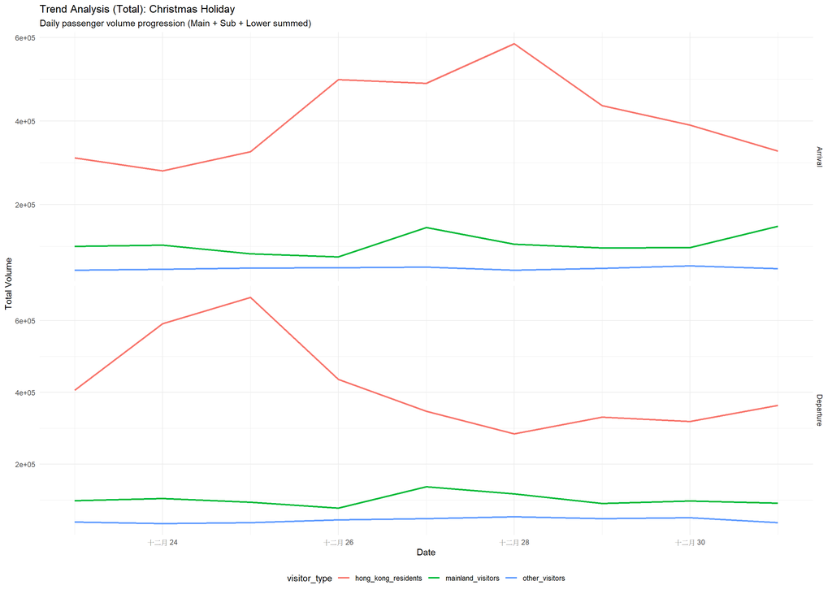

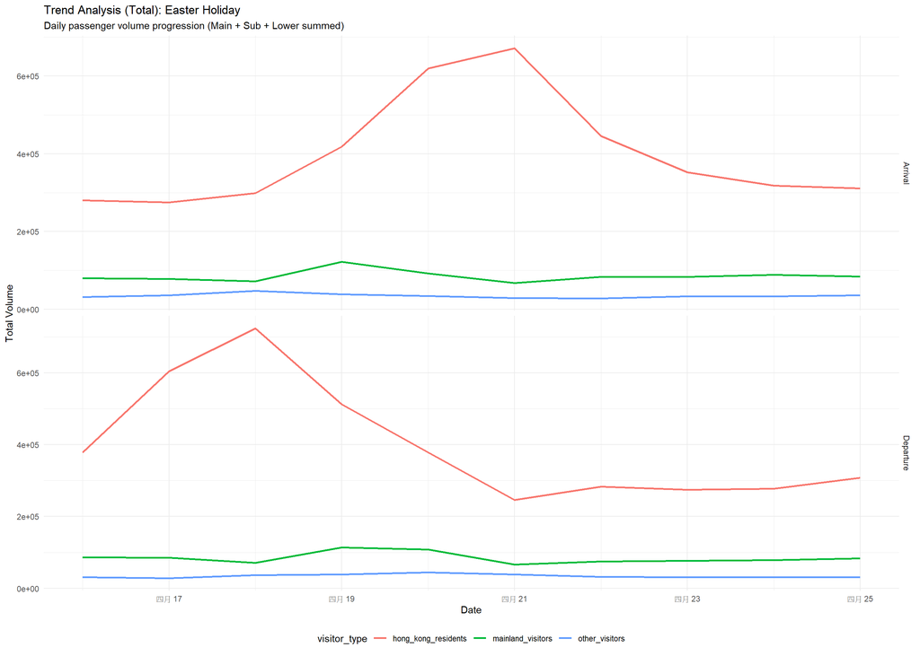

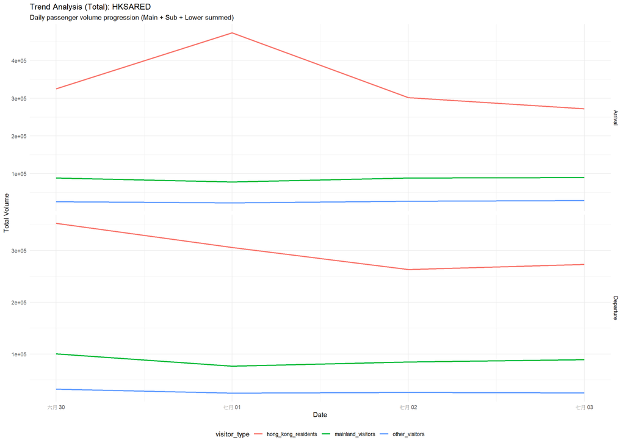

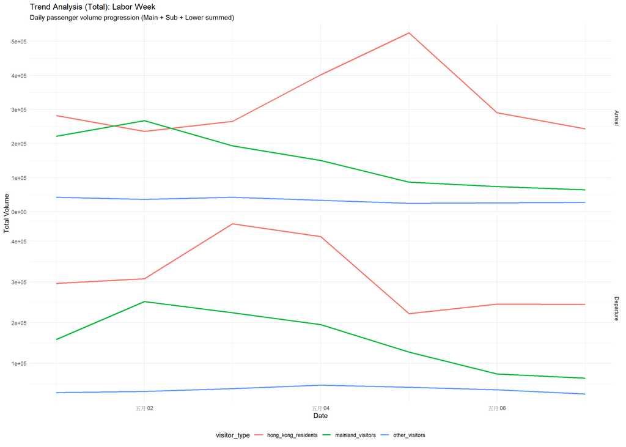

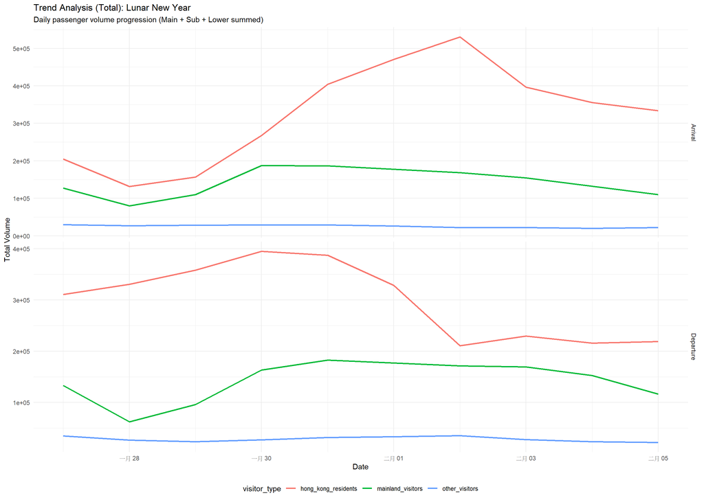

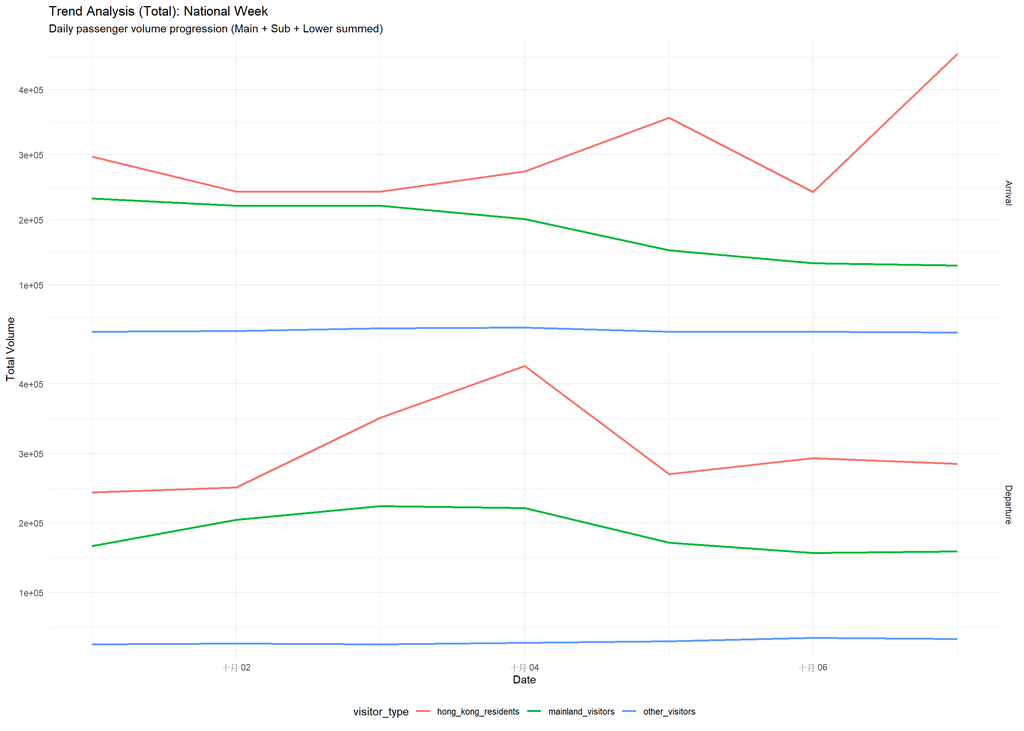

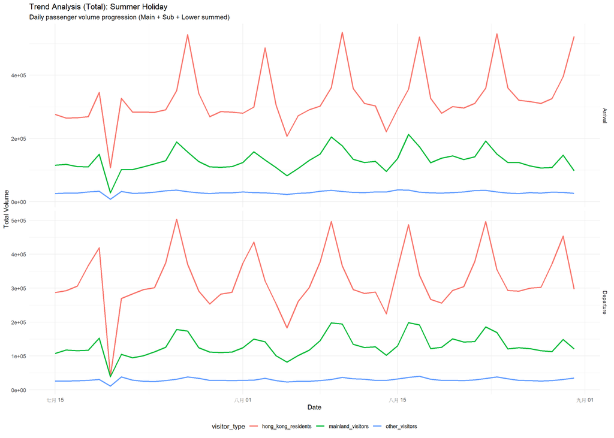

```r
# ========================================================================
# INTEGRATED PIPELINE: MODIFIED FOR AGGREGATED CATEGORIES
# ========================================================================
library(dplyr)
library(tidyr)
library(ggplot2)
library(knitr)
library(scales)
# 1. Data Preparation & Categorical Aggregation
# By omitting 'category' from the group_by, we sum them into a single total.
processed_data <- df_aggregated %>%
  rename(direction = arrival_departure) %>%
  filter(format(date, "%Y") == "2025") %>%
  pivot_longer(
    cols = c("hong_kong_residents", "mainland_visitors", "other_visitors"),
    names_to = "visitor_type",
    values_to = "Volume"
  ) %>%
  mutate(
    Period = case_when(
      date >= as.Date("2025-01-27") & date <= as.Date("2025-02-05") ~ "Lunar New Year",
      date >= as.Date("2025-04-16") & date <= as.Date("2025-04-25") ~ "Easter Holiday",
      date >= as.Date("2025-12-23") & date <= as.Date("2025-12-31") ~ "Christmas Holiday",
      date >= as.Date("2025-05-01") & date <= as.Date("2025-05-07") ~ "Labor Week",
      date >= as.Date("2025-06-30") & date <= as.Date("2025-07-03") ~ "HKSARED",
      date >= as.Date("2025-10-01") & date <= as.Date("2025-10-07") ~ "National Week",
      date >= as.Date("2025-07-15") & date <= as.Date("2025-08-31") ~ "Summer Holiday",
      TRUE ~ NA_character_
    )
  ) %>%
  filter(!is.na(Period)) %>%
  # CRITICAL AGGREGATION: We group by Period, Date, Direction, and Visitor.
  # We intentionally leave out 'category' to sum them into the total Volume.
  group_by(Period, date, direction, visitor_type) %>%
  summarise(
    Volume = sum(Volume, na.rm = TRUE),
    .groups = "drop"
  )

# 2. Prepare Summary Stats for Phase 2 (Normalized Averages)
summary_stats <- processed_data %>%
  group_by(Period, direction, visitor_type) %>%
  summarise(
    Total_Volume = sum(Volume, na.rm = TRUE),
    N_Days = n_distinct(date),
    Daily_Avg = Total_Volume / N_Days,
    .groups = "drop"
  )

# ========================================================================
# PHASE 1: TIME-SERIES TREND PLOTS (Summed Categories)
# ========================================================================
unique_periods <- unique(processed_data$Period)

for (per in unique_periods) {
  plot_df <- processed_data %>% filter(Period == per)

  p <- ggplot(plot_df, aes(x = date, y = Volume, color = visitor_type, group = visitor_type)) +
    geom_line(size = 1.0) +
    facet_grid(direction ~ ., scales = "free_y") +
    labs(
      title = paste("Trend Analysis (Total):", per),
      subtitle = "Daily passenger volume progression (Main + Sub + Lower summed)",
      x = "Date", y = "Total Volume"
    ) +
    theme_minimal() +
    theme(legend.position = "bottom")

  print(p)
}
```